# Algebra and Statistical Methods for Big Data with Bioconductor

Dolors Pelegri and Juan R. Gonzalez

Universitat de Vic - Universitat Central de Catalunya (UVic)  
ISGlobal, Centre for Research in Environmental Epidemiology (CREAL)  
Bioinformatics Research Group in Epidemiolgy (BRGE)

juanr.gonzalez@isglobal.org

2020-09-14

#### Abstract

Description of functions to perform matrix operations, algebra and some statistical models using *DelayedMatrix* objects and HDF5 data files.

#### Package

BigDataStatMeth 1.1

# 1 Prerequisites

The package requires other `Bioconductor` packages to be installed. These include: `beachmat`, `HDF5Array`, `DelayedArray`, `rhdf5`. Other required R packages are: `Matrix`, `RcppEigen` and `RSpectra`.

# 2 Overview

This package implements seveal matrix operations using `DelayMatrix` objects and HDF5 data files as well as some basic algebra operations that can be used to carry out some statistical analyses using standard methodologies such as principal component analyses or least squares estimation. The package also contains specific statatistical method mainly used in `omic` data analysis such as lasso regression.

# 3 Getting started

First, let us start by loading the required packages to describe the main capabilities of the package

```r
library(BigDataStatMeth)
library(DelayedArray)
library(rhdf5)
library(DT)
```

These other packages are required to reproduce this vignette

```r
library(microbenchmark)
```

# 4 Previous knowledge

## 4.1 HDF5 data files

Hierarchical Data Format (HDF) is a set of file formats designed to store and organize large amounts of data. It is supported by The HDF Group, a non-profit corporation whose mission is to ensure continued development of HDF5 technologies and the continued accessibility of data stored in HDF.

HDF5 is a technology suite that makes possible the management of extremely large and complex data collections, can accomodate virtually every kind of data in a single file, sequences, images, SNP matrices, and every other type of data and metadata associated with an experiment.

There is no limit on the number or size of data objects in the collection, giving great flexibility for omic data. Is high-performance I/O with a rich set of integrated performance features that allow for access time and storage space optimizations

HDF5 file structure include only *two major types of object*:

- `Datasets`, which are multidimensional arrays of a homogeneous type, in datasets we can store omics data associated to genomics, transcriptomics, epigonomics, proteomics, metabolomics experiments
- `Groups`, which are container structures which can hold datasets and other groups

This results in a truly hierarchical, filesystem-like data format

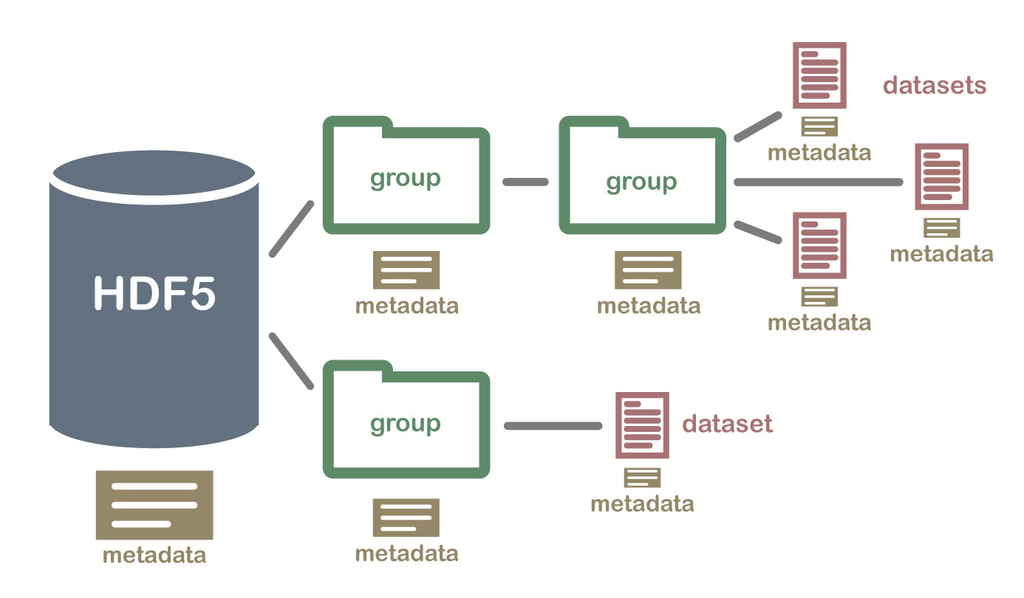

Figure 1: HDF5 hierarchical structure

## 4.2 Basics in rhdf5

**Create hdf5 file**

The `Create_HDF5_matrix_file` function implemented in this package creates an hdf5 file with a group and a dataset in one step. This function allows to create datasets from `DelayedMAtrix` objects using `beachmat` library as well as standard R matrices.

```r
library(rhdf5)
library(DelayedArray)

set.seed(5234)
n <- 100
m <- 10000
A <- matrix(rnorm(n*m,mean=0,sd=1), n,m)

Ad <- DelayedArray(A)

# Create a file with a dataset from DelayedMatrix Ad in INPUT group
Create_HDF5_matrix_file("delayed.hdf5", Ad, "INPUT", "A")
[1] 0

# We also can create a dataset from R matrix object
Create_HDF5_matrix_file("robjects.hdf5", A, "INPUT", "A")
[1] 0
```

**Add datasets in hdf5 file**

The `Create_HDF5_matrix` allows to create a dataset in existing file. We can create the dataset in any group, if group doesn’t exists in file, the group is created before append the dataset.

```r
set.seed(5234)
n <- 50
m <- 12000
B <- matrix(rnorm(n*m,mean=3,sd=0.5), n,m)

Bd <- DelayedArray(B)

# Create dataframe B with Bd matrix in delayed.hdf5 file at INPUT group
Create_HDF5_matrix(Bd, "delayed.hdf5", "INPUT", "B");
[1] 0

# Create dataframe data with Ad matrix in delayed.hdf5 file at OMIC group
set.seed(5234)
n <- 150000
m <- 50
odata <- matrix(rnorm(n*m,mean=0,sd=1), n,m)

Create_HDF5_matrix(odata, "delayed.hdf5", "OMICS", "data")
[1] 0
```

**Open and get hdf5 content file**

We can open an existing file show contents and access data using functions from `rhdf5` package. `rhdf5` is an R interface for HDF5. The file must always be opened before working with it.

```r
# Examine hierarchy before open file
h5ls("delayed.hdf5")
   group  name       otype dclass         dim
0      / INPUT   H5I_GROUP
1 /INPUT     A H5I_DATASET  FLOAT 100 x 10000
2 /INPUT     B H5I_DATASET  FLOAT  50 x 12000
3      / OMICS   H5I_GROUP
4 /OMICS  data H5I_DATASET  FLOAT 50 x 150000

# Open file
h5fdelay = H5Fopen("delayed.hdf5")
# Show hdf5 hierarchy (groups)
h5fdelay
HDF5 FILE
        name /
    filename

   name     otype dclass dim
0 INPUT H5I_GROUP
1 OMICS H5I_GROUP
```

**Access datasets data**

The $ operator can be used to access the next group level, this operator reads the object from disk. We can assign the dataset contents to an R object in order to work with it.

```r
Adata = h5fdelay$OMICS$data
Adata[1:3,1:6]
           [,1]       [,2]       [,3]       [,4]       [,5]        [,6]
[1,]  1.1245693 -0.6018349  1.6859794 0.80048363 0.82490435  0.84301868
[2,] -0.5946380 -1.3731891 -0.5045485 0.08992737 0.07191119  0.02315468
[3,]  0.1152881  0.5035297  0.5205231 0.64510203 1.47849346 -0.76030543
```

**Close hdf5 file**

After work with hdf5 we always must close the file. We can close only one file with `H5Fclose` function or close all hdf5 opend files with `h5closeAll` function

```r
# Close delayed.hdf5 file
H5Fclose(h5fdelay)

# Open 2 files and close all
h5fdelay = H5Fopen("delayed.hdf5")
h5fr = H5Fopen("robjects.hdf5")

h5closeAll()
```

More information about working with hdf5 files in r (Fischer, Pau, and Smith 2019)

# 5 Matrix Multiplication

In this section, different products of matrices and vectors are introduced. The methods implement different strategies including block multiplication algorithms and the use of parallel implementations.

## 5.1 Simple matrix multiplication

The function `blockmult()` performs a simple sequential matrix multiplication. The function allows the use of `DelayedMAtrix` objects as well as standard R matrices.

Let us simulate to set of matrices to illustrate the use of the function accross the entire documment. First, we simulate a simple case with to matrices A and B with dimensions 500x500 and 500x750, respectively. Second, another example with dimensions 1000x10000 are use to evaluate the performance in large matrices. The examples with big datasets will be illustrated using real data belonging to different omic settings. We can simulate to matrices with the desired dimensions by

```r
set.seed(123456)
n <- 500
p <- 750
A <- matrix(rnorm(n*n), nrow=n, ncol=n)
B <- matrix(rnorm(n*p), nrow=n, ncol=p)

n <- 1000
p <- 10000
Abig <- matrix(rnorm(n*n), nrow=n, ncol=n)
Bbig <- matrix(rnorm(n*p), nrow=n, ncol=p)
```

They can be converted into `DelayedMatrix` object by simply

```r
DA <- DelayedArray(A)
DB <- DelayedArray(B)
```

Matrix multiplication is then done by

```r
AxB <- blockmult(A, B)
AxBDelay <- blockmult(DA, DB)
AxBDelay [1:5,1:5]
           [,1]      [,2]      [,3]       [,4]      [,5]
[1,] -24.798007  25.79546  12.36855 -48.377086 19.950507
[2,]  24.121860 -14.53789  30.79320 -26.773787 15.879197
[3,]  26.791564 -19.11443 -10.44961 -13.119789 -9.882985
[4,]   1.310851 -30.86637  24.89040   8.327157 -3.912149
[5,] -28.554251  14.63744  23.84582 -19.025553  7.251492
```

This verifies that computations are fine, even when comparing with matrix multiplication with R (i.e. using `%*%)

```r
all.equal(AxB, AxBDelay)
[1] TRUE
all.equal(A%*%B, AxBDelay)
[1] TRUE
```

```r
AxB <- blockmult(A, B, paral = TRUE)
AxBDelay <- blockmult(DA, DB, paral = TRUE)

all.equal(AxB, AxBDelay)
[1] TRUE
```

```r
microbenchmark(
  R = A%*%B,
  noparal = blockmult(A, B),
  paral = blockmult(A, B, paral=TRUE),
  times = 10)
Unit: milliseconds
    expr       min        lq      mean    median        uq       max neval cld
       R 120.57191 133.03909 140.06404 137.42144 146.40156 168.93854    10   b
 noparal  37.47245  38.24997  40.32871  38.97213  43.07964  45.64929    10  a
   paral  37.34630  38.14834  41.44649  40.37072  44.47999  47.53665    10  a
```

With `paral=TRUE`, an optional parameter threads can be used to indicate the number of `threads` to launch simultaneously, if `threads=NULL` the function takes the available threads - 1, leaving one available for user.

```r
AxB <- blockmult(A, B, paral = TRUE, threads = 2)
AxBDelay <- blockmult(DA, DB, paral = TRUE, threads = 3)

all.equal(AxB, AxBDelay)
[1] TRUE
```

We can show how the number of threads affects performance.

```r
microbenchmark(
  AxBnThread2 = blockmult(DA, DB, paral = TRUE, threads = 2) ,
  AxBnThread3 = blockmult(DA, DB, paral = TRUE, threads = 3) ,
  AxBnThread4 = blockmult(DA, DB, paral = TRUE, threads = 4) ,
  times = 10)
Unit: milliseconds
        expr      min       lq     mean   median       uq      max neval cld
 AxBnThread2 48.87721 51.71826 55.41897 54.26715 58.57948 65.94197    10   a
 AxBnThread3 47.90815 51.17400 57.45699 58.11388 63.97138 65.89796    10   a
 AxBnThread4 49.37920 51.03682 56.90817 52.53500 61.73989 77.75741    10   a
```

## 5.2 Block matrix multiplication

Matrix multiplication using block matrices is implemented in the `blockmult()` function. It only requires to setting the argument `block_size` different from 0, by default `block_size = 128`.

```r
AxB <- blockmult(A, B, block_size = 10)
AxBDelay <- blockmult(DA, DB, block_size = 10 )
```

As expected the results obtained using this procedure are the correct ones

```r
all.equal(AxBDelay,A%*%B)
[1] TRUE
all.equal(AxB, AxBDelay)
[1] TRUE
```

Note that when the argument `block_size` is larger than any of the dimensions of matrix A or B the `blocks_size` is set to `min(cols(A), rows(A), cols(B), rows(B))`.

As in the case of using a simple matrix multiplication, one can make the operations in parallel with `paral = TRUE` and optionally indicating the number of threads to use in parallel computing .

```r
AxB <- blockmult(A, B, block_size = 10, paral = TRUE)
AxBDelay <- blockmult(DA, DB, block_size = 10, paral = TRUE )
AxBDelayT <- blockmult(DA, DB, block_size = 10, paral = TRUE, threads =  3 )

all.equal(AxBDelay,A%*%B)
[1] TRUE
all.equal(AxB, AxBDelay)
[1] TRUE
all.equal(AxBDelay, AxBDelayT)
[1] TRUE
```

To work with big matrices `blockmult()` saves matrices in hdf5 file format in order to be able to operate with them in blocks and not overload the memory, by default are considered large matrices if the number of rows or columns is greater than 5000, but it can be changed with `bigmatrix` argument.

```r
DAbig <- DelayedArray(Abig)
DBbig <- DelayedArray(Abig)

# We consider a big matrix if number of rows or columns are > 500
AxBBig3000 <- blockmult(DAbig, DBbig, bigmatrix = 500)

# We want to force it to run in memory
AxBNOBig <- blockmult(DAbig, DBbig, bigmatrix = 100000)
```

Depending on whether the calculation has been performed directly in memory or from an hdf5 file, the returned object type is different.

If we work in memory results are returned as a current r matrix object,

```r
class(AxBNOBig)
[1] "matrix"
AxBNOBig[1:5,1:5]
           [,1]       [,2]      [,3]       [,4]      [,5]
[1,]   6.906941  56.240861 -81.68187 -36.925101 -42.36525
[2,]   8.353795  79.371434  -3.13127  19.532005 -29.78580
[3,] -28.130259 -22.960250  10.39253  -1.524004  13.95016
[4,]   6.917426  36.972565 -18.90454   4.413286  10.56029
[5,] -58.796247   8.764894  26.81915  68.773862  28.42892
```

if we work in disk, we return an hdf5 object with two groups (hdf5 group is a container mechanism by which HDF5 files are organized), INPUT and OUTPUT, in INPUT group we have the input matrices A and B, in OUTPUT group we get the resulting matrix C.

To work in R with hdf5 data object we can use the `rhdf5` function library from `bioconductor`,

```r
class(AxBBig3000)
[1] "list"

# Assign hdf5 result content to R variable reshdf5
reshdf5 <- AxBBig3000$res$OUTPUT$C
reshdf5[1:5,1:5]
           [,1]       [,2]      [,3]       [,4]      [,5]
[1,]   6.906941  56.240861 -81.68187 -36.925101 -42.36525
[2,]   8.353795  79.371434  -3.13127  19.532005 -29.78580
[3,] -28.130259 -22.960250  10.39253  -1.524004  13.95016
[4,]   6.917426  36.972565 -18.90454   4.413286  10.56029
[5,] -58.796247   8.764894  26.81915  68.773862  28.42892

all.equal(reshdf5, AxBNOBig)
[1] TRUE
```

Like in rhdf5 it is important to close all dataset, group, and file handles when not used anymore,

```r
bdclose(AxBBig3000)
```

Here, we compare the performace of the block method with the different options.

```r
bench1 <- microbenchmark(
  noblockParal = blockmult(Abig, Bbig, paral = TRUE),
  blockParalfile = blockmult(Abig, Bbig, block_size = 256, paral=TRUE),
  blockParalmem = blockmult(Abig, Bbig, block_size = 256, paral=TRUE,
                            bigmatrix = 100000),
  times = 3 )

bench1
Unit: seconds
           expr       min        lq      mean    median        uq       max neval cld
   noblockParal 12.385815 12.503017 13.064251 12.620219 13.403469 14.186719     3   c
 blockParalfile  6.067793  6.184433  6.547299  6.301073  6.787053  7.273032     3  b
  blockParalmem  1.824930  1.867262  1.928982  1.909593  1.981007  2.052421     3 a
```

The same information is depicted in the next Figure which illustrates the comparison between the different assessed methods

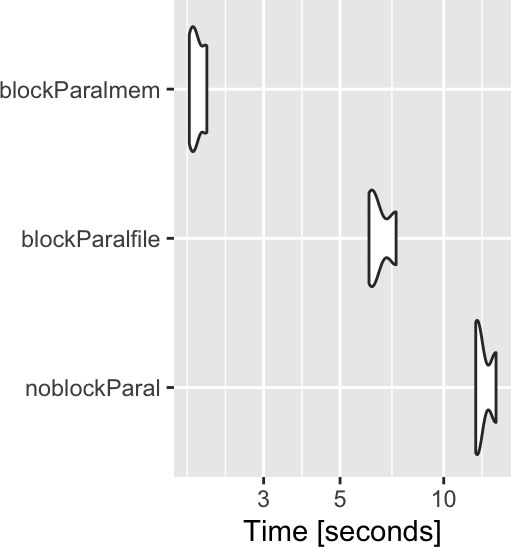

```r
ggplot2::autoplot(bench1)
```

Plot shows that the execution time in hdf5 files is greater than memory execution time, this is due to the read and write time required to access to disk data. At higher disk speed better performance.

# 6 Cross-product and Transposed Cross-product

To perform a cross-product $C = A^t A$ you can call `bdcrossprod()` function.

```r
n <- 500
m <- 250
A <- matrix(rnorm(n*m), nrow=n, ncol=m)
DA <- DelayedArray(A)

# Cross Product of a standard R matrix
cpA <- bdcrossprod(A)
# Result with DelayedArray data type
cpDA <- bdcrossprod(DA)
```

We obtain the expected values computed using `crossprod` function

```r
all.equal(cpDA, crossprod(A))
[1] TRUE
```

you may also set `transposed=TRUE` (default value transposed=false) to get a transposed cross-product $C = A A^t$

```r
# Transposed Cross Product R matrices
tcpA <- bdcrossprod(A, transposed = TRUE)
# With DelayeArray data types
tcpDA <- bdcrossprod(DA, transposed = TRUE)
```

We obtain the expected values computed using `tcrossprod` function

```r
all.equal(tcpDA, tcrossprod(A))
[1] TRUE
```

We can show that the implemented version really improves the R implementation computational speed.

```r
bench <- microbenchmark(
  bdcrossp = bdcrossprod(DA, transposed = TRUE),
  rcrossp = tcrossprod(A),
  times = 1)  # Only DEBUG MODE
  # times = 10) # PRODUCTION MODE
bench
Unit: milliseconds
     expr      min       lq     mean   median       uq      max neval
 bdcrossp 11.53832 11.53832 11.53832 11.53832 11.53832 11.53832     1
  rcrossp 25.12502 25.12502 25.12502 25.12502 25.12502 25.12502     1
```

# 7 Matrix Vector Multiplication

You can perform a weighted cross-product $C = X^ t w X$ with `bdwcrossprod()` given a matrix X as argument and a vector or matrix of weights, w.

## 7.1 Weighted Cross-product and Weighted Transposed Cross-product

```r
n <- 250
X <- matrix(rnorm(n*n), nrow=n, ncol=n)
u <- runif(n)
w <- u * (1 - u)
DX <- DelayedArray(X)
Dw <- DelayedArray(as.matrix(w))

wcpX <- bdwproduct(X, w,"xwxt")
wcpDX <- bdwproduct(DX, Dw,"xwxt") # with DelayedArray

wcpDX[1:5,1:5]
          [,1]       [,2]      [,3]       [,4]       [,5]
[1,] 44.566643 -1.1443388  2.008108 -1.8534484  2.8048958
[2,] -1.144339 44.7375240  4.331431  0.5470362 -0.5210717
[3,]  2.008108  4.3314306 44.334277 -3.6845822  4.6351765
[4,] -1.853448  0.5470362 -3.684582 35.1744289  0.6967215
[5,]  2.804896 -0.5210717  4.635177  0.6967215 38.6863330
```

Those are the expected values as it is indicated by executing:

```r
all.equal( wcpDX, X%*%diag(w)%*%t(X) )
[1] TRUE
```

## 7.2 Weighted Transposed Cross Product

With argument `transposed=TRUE`, we can perform a transposed weighted cross-product $C = A w A^t$

```r
wtcpX <- bdwproduct(X, w,"xtwx")
wtcpDX <- bdwproduct(DX, Dw,"xtwx") # with DelayedArray

wtcpDX[1:5,1:5]
           [,1]       [,2]       [,3]       [,4]       [,5]
[1,] 42.6182878  0.1713293 -3.4083986 -0.1255156 -0.8229967
[2,]  0.1713293 36.6035590  2.4290292 -0.9855219  0.8330007
[3,] -3.4083986  2.4290292 34.1964223  0.4676414 -0.6890005
[4,] -0.1255156 -0.9855219  0.4676414 40.5834290 -2.0438188
[5,] -0.8229967  0.8330007 -0.6890005 -2.0438188 34.8288107
```

Those are the expected values as it is indicated by executing:

```r
all.equal(wtcpDX, t(X)%*%diag(w)%*%X)
[1] TRUE
```

# 8 Inverse Cholesky

The Cholesky factorization is widely used for solving a system of linear equations whose coefficient matrix is symmetric and positive definite.

$$A = LL^t = U^tU$$

where $L$ is a lower triangular matrix and U is an upper triangular matrix. To get the Inverse Cholesky we can use the function `bdInvCholesky()`. Let us start by illustrating how to do this computations in a simulated data:

```r
# Generate a positive definite matrix
Posdef <- function (n, ev = runif(n, 0, 10))
{
  Z <- matrix(ncol=n, rnorm(n^2))
  decomp <- qr(Z)
  Q <- qr.Q(decomp)
  R <- qr.R(decomp)
  d <- diag(R)
  ph <- d / abs(d)
  O <- Q %*% diag(ph)
  Z <- t(O) %*% diag(ev) %*% O
  return(Z)
}

A <- Posdef(n = 500, ev = 1:500)
DA <- DelayedArray(A)

invchol <- bdInvCholesky(A)
Dinvchol <- bdInvCholesky(DA)

round(invchol[1:5,1:5],8)
            [,1]        [,2]        [,3]        [,4]        [,5]
[1,]  0.01481736 -0.00308175 -0.00272473 -0.00038127  0.00208968
[2,] -0.00308175  0.01394900  0.00423320  0.00198972  0.00135516
[3,] -0.00272473  0.00423320  0.01292554 -0.00028941 -0.00070686
[4,] -0.00038127  0.00198972 -0.00028941  0.01344189  0.00130492
[5,]  0.00208968  0.00135516 -0.00070686  0.00130492  0.01457558
```

We can check whether this function returns the expected values obtained with the standard R function `solve`:

```r
all.equal(Dinvchol, solve(A))
[1] TRUE
```

# 9 Singular Value Decomposition (SVD)

The SVD of an $m \times n$ real or complex matrix $A$ is a factorization of the form:

$$U\Sigma { V }^{ T }$$

where :

-$U$ is a $m \times m$ real or complex unitary matrix -$\Sigma$ is a $m \times n$ rectangular diagonal matrix with non-negative real numbers on the diagonal -$V$ is a $n \times n$ real or complex unitary matrix.

Notice that:

- The diagonal entries $\sigma_i$ of $\Sigma$ are known as the singular values of $A$.
- The columns of $U$ are called the left-singular vectors of $A$.
- The columns of $V$ are called the right-singular vectors of $A$.

## 9.1 Simple Singular Values Decomposition

He have implemented the SVD for R matrices and Delayed Array objects in the function `bdSVD()`. The method, so far, only allows SVD of real matrices $A$. This code illustrate how to perform such computations:

```r
# Matrix simulation
set.seed(413)
n <- 500
A <- matrix(rnorm(n*n), nrow=n, ncol=n)
# Get a Delayed Array object
DA <- DelayedArray(A)

# SVD
bsvd <- bdSVD(A)
Dbsvd <- bdSVD(DA)

# Singular values, and right and left singular vectors
bsvd$d[1:5]
[1] 44.27037 43.95609 43.31037 43.01980 42.81728
bsvd$u[1:5,1:5]
             [,1]        [,2]         [,3]         [,4]         [,5]
[1,]  0.028712445  0.10169472  0.019783036  0.032804622 -0.048915416
[2,]  0.001193891  0.02296487  0.009024529  0.059683600  0.027888834
[3,] -0.008878497 -0.02414059 -0.006035909 -0.004867886  0.024570252
[4,]  0.037323916 -0.04675198  0.035928628 -0.021097593 -0.073485962
[5,] -0.054073083  0.04382626 -0.009027050 -0.002269443 -0.003071978
bsvd$v[1:5,1:5]
            [,1]        [,2]        [,3]        [,4]         [,5]
[1,] -0.07105335  0.04554495 -0.03850442  0.07270812  0.078124410
[2,]  0.05989691 -0.02957792 -0.07508850 -0.01171385  0.001581823
[3,] -0.00200688 -0.04179449  0.02798939 -0.05686766 -0.073573833
[4,] -0.01284403 -0.05024617 -0.09038993 -0.05725360  0.023632656
[5,] -0.01751359  0.07320492 -0.02120536 -0.02397367 -0.067643671
```

We get the expected results obtained with standard R functions:

```r
all.equal( sqrt( svd( tcrossprod( scale(A) ) )$d[1:10] ), bsvd$d[1:10] )
[1] TRUE
all.equal( sqrt( svd( tcrossprod( scale(A) ) )$d[1:10] ), Dbsvd$d[1:10] )
[1] TRUE
```

you get the $\sigma_i$, $U$ and $V$ of normalized matrix $A$, if you want to perform the SVD from not normalized matrix $A$ then you have to set the parameter `bcenter = false` and `bscale = false`.

```r
bsvd <- bdSVD(A, bcenter = FALSE, bscale = FALSE)
Dbsvd <- bdSVD(DA, bcenter = FALSE, bscale = FALSE)


bsvd$d[1:5]
[1] 44.44007 43.89640 43.38384 43.23563 42.82658
bsvd$u[1:5,1:5]
              [,1]        [,2]         [,3]         [,4]        [,5]
[1,]  3.075740e-02  0.09861737 -0.026705796  0.001569226 -0.04384078
[2,]  6.480471e-05  0.04151230 -0.049215808  0.054763599 -0.01436232
[3,] -1.857597e-02 -0.02463540 -0.001246071  0.015838141  0.05725309
[4,]  3.555600e-02 -0.05715730 -0.009596880 -0.040247700 -0.03888504
[5,] -5.290501e-02  0.04784627 -0.006624289  0.010168748  0.01934154
bsvd$v[1:5,1:5]
              [,1]        [,2]         [,3]        [,4]        [,5]
[1,] -0.0677291931  0.03646765 -0.072013679 -0.06460296  0.03834539
[2,]  0.0558086446 -0.02816709 -0.067619533  0.02478961  0.01316491
[3,]  0.0024305441 -0.04679000  0.064115513  0.04134591 -0.03519768
[4,] -0.0007861777 -0.06602592 -0.062833191  0.06307396  0.03651487
[5,] -0.0165396063  0.07316212  0.002600021  0.07030477 -0.07916813

all.equal( sqrt(svd(tcrossprod(A))$d[1:10]), bsvd$d[1:10] )
[1] TRUE
all.equal( sqrt(svd(tcrossprod(A))$d[1:10]), Dbsvd$d[1:10] )
[1] TRUE
```